# Latihan Pertemuan 3

Aurelia Fury

2026-09-03

# Packages

```r
library(dLagM)
library(dynlm)
library(MLmetrics)
library(lmtest)
library(car)
```

# Impor Data

```r
# Data Latihan 1 - Market Share & Price (20 periode)
period <- 1:20
market_share <- c(3.63,4.20,3.33,4.54,2.89,4.87,4.90,5.29,6.18,7.20,
                   7.25,6.09,6.80,8.65,8.43,8.29,7.18,7.90,8.45,8.23)
price <- c(0.97,0.95,0.99,0.91,0.98,0.90,0.89,0.86,0.85,0.82,
           0.79,0.83,0.81,0.77,0.76,0.80,0.83,0.79,0.76,0.78)
data1 <- data.frame(period, market_share, price)
str(data1)
```

```
## 'data.frame':    20 obs. of  3 variables:
##  $ period      : int  1 2 3 4 5 6 7 8 9 10 ...
##  $ market_share: num  3.63 4.2 3.33 4.54 2.89 4.87 4.9 5.29 6.18 7.2 ...
##  $ price       : num  0.97 0.95 0.99 0.91 0.98 0.9 0.89 0.86 0.85 0.82 ...
```

```r
# Data Latihan 2 - Sales & Advertising (40 tahun)
year <- 1975:2014
sales <- c(11.7,12.0,12.3,12.8,13.1,13.6,13.9,14.4,14.7,15.3,
           15.5,15.8,16.1,16.6,16.9,16.7,16.9,17.4,17.6,17.9,
           18.0,17.9,18.0,18.2,18.2,18.3,18.6,19.2,19.3,19.5,
           19.2,19.3,19.5,20.0,20.0,19.9,19.8,19.9,20.2,21.0)
advertising <- c(9.4,9.6,10.0,10.4,10.8,10.9,11.7,12.2,12.5,12.9,
                  13.0,13.2,13.8,14.2,14.6,14.4,15.0,15.4,15.7,15.9,
                  15.9,16.0,16.3,16.2,16.8,17.3,17.6,18.1,18.3,18.5,
                  18.7,18.9,19.2,20.0,20.0,20.3,20.4,21.0,21.5,22.1)
data2 <- data.frame(year, sales, advertising)
str(data2)
```

```
## 'data.frame':    40 obs. of  3 variables:
##  $ year       : int  1975 1976 1977 1978 1979 1980 1981 1982 1983 1984 ...
##  $ sales      : num  11.7 12 12.3 12.8 13.1 13.6 13.9 14.4 14.7 15.3 ...
##  $ advertising: num  9.4 9.6 10 10.4 10.8 10.9 11.7 12.2 12.5 12.9 ...
```

# Latihan 1 - Distributed Lag Model (Market Share terhadap Price)

Model distributed lag menyatakan bahwa peubah dependen $Y$ (Market Share) dipengaruhi oleh peubah independen $X$ (Price) baik pada waktu sekarang maupun beberapa periode ke belakang ($X_t, X_{t-1}, X_{t-2}, ...$).

## Pembagian Data

```r
train1 <- data1[1:15, ]
test1  <- data1[16:20, ]

train1.ts <- ts(train1)
test1.ts  <- ts(test1)
data1.ts  <- ts(data1)
```

## Pemodelan (Lag = 2)

Pemodelan model Regression with Distributed Lag dengan R dapat menggunakan `dLagM::dlm()`. Sebagai awal, akan dicoba model dengan panjang lag $q=2$.

```r
model1.dlm <- dlm(x = train1$price, y = train1$market_share, q = 2)
summary(model1.dlm)
```

```
##
## Call:
## lm(formula = model.formula, data = design)
##
## Residuals:
##      Min       1Q   Median       3Q      Max
## -0.55526 -0.24858 -0.08971  0.20176  0.65633
##
## Coefficients:
##              Estimate Std. Error t value Pr(>|t|)
## (Intercept)  26.29549    1.69541  15.510 8.44e-08 ***
## x.t         -24.13651    4.05335  -5.955 0.000214 ***
## x.1          -0.00163    3.20631  -0.001 0.999606
## x.2           0.34290    4.21417   0.081 0.936929
## ---
## Signif. codes:  0 '***' 0.001 '**' 0.01 '*' 0.05 '.' 0.1 ' ' 1
##
## Residual standard error: 0.4366 on 9 degrees of freedom
## Multiple R-squared:  0.9553, Adjusted R-squared:  0.9404
## F-statistic: 64.06 on 3 and 9 DF,  p-value: 2.151e-06
##
## AIC and BIC values for the model:
##        AIC     BIC
## 1 20.56206 23.3868
```

```r
AIC(model1.dlm)
```

```
## [1] 20.56206
```

```r
BIC(model1.dlm)
```

```
## [1] 23.3868
```

## Peramalan dan Akurasi

```r
fore1.dlm <- forecast(model = model1.dlm, x = test1$price, h = 5)
fore1.dlm
```

```
## $forecasts
## [1] 7.249082 6.521493 7.500621 8.235068 7.738671
##
## $call
## forecast.dlm(model = model1.dlm, x = test1$price, h = 5)
##
## attr(,"class")
## [1] "forecast.dlm" "dLagM"
```

```r
mape1.dlm <- MAPE(fore1.dlm$forecasts, test1$market_share)
mape1.dlm #akurasi data uji
```

```
## [1] 0.0705934
```

```r
GoF(model1.dlm) #akurasi data latih
```

```
##             n       MAE           MPE       MAPE      sMAPE      MASE       MSE
## model1.dlm 13 0.3009786 -0.0004896023 0.05451787 0.05541524 0.3236329 0.1319396
##                MRAE     GMRAE
## model1.dlm 1.474088 0.3515233
```

## Lag Optimum

Untuk menentukan panjang lag optimum, digunakan `finiteDLMauto()` yang membandingkan berbagai panjang lag berdasarkan nilai AIC.

```r
finiteDLMauto(formula = market_share ~ price,
              data = data.frame(train1), q.min = 1, q.max = 10,
              model.type = "dlm", error.type = "AIC", trace = TRUE)
```

```
##    q - k    MASE      AIC      BIC   GMRAE    MBRAE R.Adj.Sq  Ljung-Box
## 7      7 0.00000     -Inf     -Inf 0.00000  0.00000      NaN        NaN
## 8      8 0.00000     -Inf     -Inf 0.00000  0.00000      NaN        NaN
## 9      9 0.00000     -Inf     -Inf 0.00000  0.00000      NaN        NaN
## 10    10 0.00000     -Inf     -Inf 0.00000  0.00000      NaN        NaN
## 6      6 0.08453 -4.06421 -2.28919 0.11903 -0.33129  0.97249 0.04562035
## 3      3 0.27946 14.41990 17.32934 0.49694 -0.34334  0.95685 0.87839563
## 5      5 0.30204 15.91911 18.33979 0.49375 -0.33012  0.89375 0.34730411
## 4      4 0.29388 16.21356 18.99882 0.48458 -0.05971  0.94508 0.68007694
## 1      1 0.35387 19.92429 22.48052 0.47815  1.13162  0.94457 0.32743011
## 2      2 0.32363 20.56206 23.38680 0.35152 -0.40855  0.94035 0.68818708
```

Lag optimum dipilih berdasarkan nilai **AIC terkecil** pada tabel di atas. Perhatikan bahwa baris $q=7$ sampai $q=10$ menunjukkan AIC $=-\infty$ — ini bukan model yang valid, melainkan tanda **model jenuh/*overfit*** (jumlah parameter yang diduga terlalu banyak dibanding sisa derajat bebas data latih). Nilai AIC valid terkecil sesungguhnya berada pada $q=6$ (AIC $=-4,064$), sehingga $q=6$ inilah yang dipilih sebagai lag optimum.

```r
# Lag optimum berdasarkan finiteDLMauto() (AIC valid terkecil, bukan baris -Inf yang overfit)
q_opt1 <- 6
model1.dlm.opt <- dlm(x = train1$price, y = train1$market_share, q = q_opt1)
summary(model1.dlm.opt)
```

```
##
## Call:
## lm(formula = model.formula, data = design)
##
## Residuals:
##        1        2        3        4        5        6        7        8
## -0.06257  0.05379  0.06679 -0.05236 -0.03731  0.04871 -0.07404  0.12979
##        9
## -0.07279
##
## Coefficients:
##             Estimate Std. Error t value Pr(>|t|)
## (Intercept)  37.4332     2.7496  13.614   0.0467 *
## x.t         -43.9959     5.1527  -8.538   0.0742 .
## x.1           1.3336     4.4868   0.297   0.8161
## x.2           0.6599     2.9610   0.223   0.8604
## x.3           0.3176     3.5214   0.090   0.9427
## x.4          16.6181     5.4842   3.030   0.2029
## x.5           1.3711     3.0017   0.457   0.7272
## x.6         -13.6131     4.2894  -3.174   0.1943
## ---
## Signif. codes:  0 '***' 0.001 '**' 0.01 '*' 0.05 '.' 0.1 ' ' 1
##
## Residual standard error: 0.2131 on 1 degrees of freedom
## Multiple R-squared:  0.9966, Adjusted R-squared:  0.9725
## F-statistic:  41.4 on 7 and 1 DF,  p-value: 0.1191
##
## AIC and BIC values for the model:
##         AIC       BIC
## 1 -4.064207 -2.289185
```

```r
AIC(model1.dlm.opt)
```

```
## [1] -4.064207
```

```r
BIC(model1.dlm.opt)
```

```
## [1] -2.289185
```

```r
fore1.dlm.opt <- forecast(model = model1.dlm.opt, x = test1$price, h = 5)
mape1.dlm.opt <- MAPE(fore1.dlm.opt$forecasts, test1$market_share)
mape1.dlm.opt #akurasi data uji
```

```
## [1] 0.06368703
```

```r
GoF(model1.dlm.opt) #akurasi data latih
```

```
##                n        MAE           MPE        MAPE       sMAPE       MASE
## model1.dlm.opt 9 0.06646092 -8.151672e-05 0.009854368 0.009858763 0.08452899
##                        MSE      MRAE     GMRAE
## model1.dlm.opt 0.005044506 0.1947309 0.1190314
```

## Perbandingan Model Latihan 1

```r
akurasi1 <- matrix(c(mape1.dlm, mape1.dlm.opt))
row.names(akurasi1) <- c(paste0("DLM (q=2)"), paste0("DLM (q optimum)"))
colnames(akurasi1) <- "MAPE"
akurasi1
```

```
##                       MAPE
## DLM (q=2)       0.07059340
## DLM (q optimum) 0.06368703
```

Model dengan **MAPE data uji terkecil** adalah model terbaik untuk kasus Market Share terhadap Price ini. Model $q=6$ (lag optimum) memiliki MAPE data uji $\approx 6,37\%$, sedikit lebih kecil dibanding model $q=2$ ($\text{MAPE}=7,06\%$), sehingga model dengan lag optimum ($q=6$) yang dipilih sebagai **model terbaik** untuk Latihan 1. Namun perlu dicatat, model $q=6$ hanya memiliki **1 derajat bebas sisaan** (residual standard error dihitung dari 9 observasi dengan 8 parameter) — model ini hampir jenuh (*near-saturated*) dan estimasi koefisiennya sangat tidak stabil, sehingga keunggulan MAPE-nya perlu diinterpretasikan dengan hati-hati (rawan *overfitting*, bukan murni karena model lebih baik secara struktural).

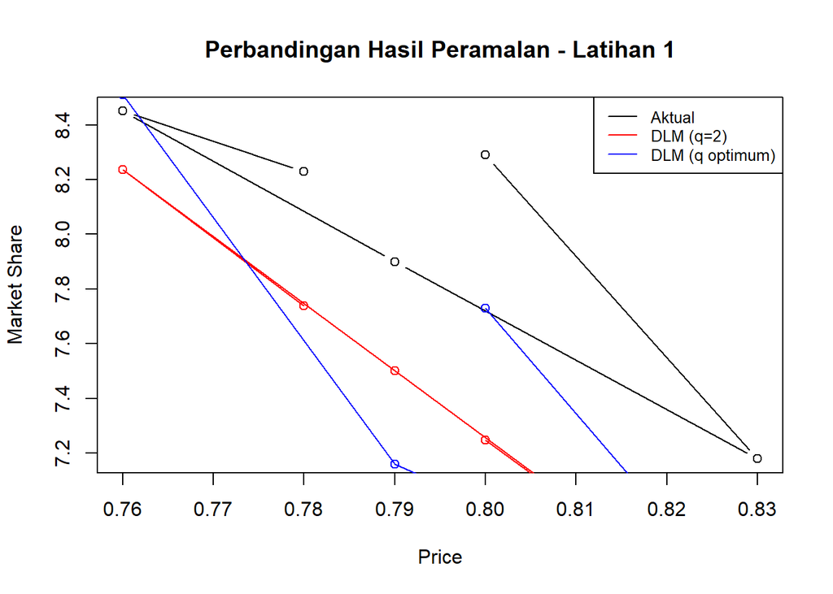

```r
par(mfrow = c(1,1))
plot(test1$price, test1$market_share, type = "b", col = "black",
     xlab = "Price", ylab = "Market Share", main = "Perbandingan Hasil Peramalan - Latihan 1")
points(test1$price, fore1.dlm$forecasts, col = "red");      lines(test1$price, fore1.dlm$forecasts, col = "red")
points(test1$price, fore1.dlm.opt$forecasts, col = "blue"); lines(test1$price, fore1.dlm.opt$forecasts, col = "blue")
legend("topright", c("Aktual", "DLM (q=2)", "DLM (q optimum)"),
       lty = 1, col = c("black", "red", "blue"), cex = 0.8)
```

# Latihan 2 - Autoregressive Distributed Lag / ARDL (Sales terhadap Advertising)

Model ARDL menyatakan bahwa peubah dependen $Y$ (Sales) dipengaruhi oleh peubah independen $X$ (Advertising) baik pada waktu sekarang maupun lag-nya ($X_t, X_{t-1}, ..., X_{t-q}$), **dan juga** oleh lag dari dirinya sendiri ($Y_{t-1}, ..., Y_{t-p}$).

## Pembagian Data

```r
train2 <- data2[1:30, ]
test2  <- data2[31:40, ]

train2.ts <- ts(train2)
test2.ts  <- ts(test2)
data2.ts  <- ts(data2)
```

## Pemodelan (p = 1, q = 1)

Pemodelan Autoregressive/ARDL dengan R dapat menggunakan `dLagM::ardlDlm()`.

```r
model2.ardl <- ardlDlm(formula = sales ~ advertising, data = train2, p = 1, q = 1)
summary(model2.ardl)
```

```
##
## Time series regression with "ts" data:
## Start = 2, End = 30
##
## Call:
## dynlm(formula = as.formula(model.text), data = data)
##
## Residuals:
##       Min        1Q    Median        3Q       Max
## -0.229277 -0.127437  0.009143  0.109228  0.259132
##
## Coefficients:
##               Estimate Std. Error t value Pr(>|t|)
## (Intercept)    1.55786    0.44353   3.512  0.00171 **
## advertising.t  0.29110    0.13707   2.124  0.04376 *
## advertising.1 -0.09584    0.16067  -0.596  0.55621
## sales.1        0.74360    0.09964   7.463 8.14e-08 ***
## ---
## Signif. codes:  0 '***' 0.001 '**' 0.01 '*' 0.05 '.' 0.1 ' ' 1
##
## Residual standard error: 0.1576 on 25 degrees of freedom
## Multiple R-squared:  0.9955, Adjusted R-squared:  0.9949
## F-statistic:  1830 on 3 and 25 DF,  p-value: < 2.2e-16
```

```r
AIC(model2.ardl)
```

```
## [1] -19.18177
```

```r
BIC(model2.ardl)
```

```
## [1] -12.34529
```

## Peramalan dan Akurasi

```r
fore2.ardl <- forecast(model = model2.ardl, x = t(as.matrix(test2$advertising)), h = 10)
fore2.ardl
```

```
## $forecasts
##  [1] 19.72862 19.93768 20.16129 20.53170 20.73047 20.96560 21.14081 21.43616
##  [9] 21.74384 22.09937
##
## $call
## forecast.ardlDlm(model = model2.ardl, x = t(as.matrix(test2$advertising)),
##     h = 10)
##
## attr(,"class")
## [1] "forecast.ardlDlm" "dLagM"
```

```r
mape2.ardl <- MAPE(fore2.ardl$forecasts, test2$sales)
mape2.ardl #akurasi data uji
```

```
## [1] 0.0484832
```

```r
GoF(model2.ardl) #akurasi data latih
```

```
##              n       MAE           MPE        MAPE       sMAPE      MASE
## model2.ardl 29 0.1238592 -0.0001484019 0.007696613 0.007697173 0.4281553
##                   MSE     MRAE     GMRAE
## model2.ardl 0.0214047 81884782 0.7548444
```

## Orde (p,q) Optimum

```r
model2.ardl.opt <- ardlBoundOrders(data = data.frame(train2), ic = "AIC",
                                    formula = sales ~ advertising)
model2.ardl.opt
```

```
## $p
##   advertising
## 1           9
##
## $q
## [1] 5
##
## $Stat.table
##             q = 1      q = 2      q = 3     q = 4      q = 5     q = 6
## p = 1  -17.699638 -15.159785 -11.171253 -12.97933  -9.595366 -13.27011
## p = 2  -15.479841 -13.700376  -9.602500 -11.28856  -8.094541 -11.38500
## p = 3  -12.842321 -12.842321 -11.353394 -12.78397 -10.302797 -12.74830
## p = 4  -10.635346  -8.929704  -8.929704 -12.70373  -9.983369 -12.65121
## p = 5   -9.806117 -13.826706 -13.057325 -13.05733 -11.391142 -15.09657
## p = 6  -10.952036 -11.769321  -9.940426 -13.06169 -13.061688 -14.01520
## p = 7  -16.758977 -26.261218 -24.852544 -25.47848 -24.699579 -24.69958
## p = 8  -17.228470 -37.897273 -36.101045 -37.99830 -36.004045 -40.37030
## p = 9  -15.247022 -25.453391 -37.081485 -47.43756 -52.877759        NA
## p = 10 -16.426957 -25.692234 -33.670479        NA         NA        NA
## p = 11 -24.297308         NA         NA        NA         NA        NA
##             q = 7      q = 8      q = 9     q = 10    q = 11 q = 12 q = 13
## p = 1   -8.733676  -6.780325  -2.406017 -11.832556 -31.13954     NA     NA
## p = 2   -6.791005  -6.094917  -1.950582  -9.840686 -32.26806     NA     NA
## p = 3   -8.116889  -6.050750  -5.212960  -7.840793        NA     NA     NA
## p = 4   -8.021885  -6.468408  -4.559211  -6.112776        NA     NA     NA
## p = 5  -10.474985 -13.381567 -46.224394         NA        NA     NA     NA
## p = 6   -9.433391 -11.477147 -44.228354         NA        NA     NA     NA
## p = 7  -27.814134 -37.722738         NA         NA        NA     NA     NA
## p = 8  -40.370303 -38.812165         NA         NA        NA     NA     NA
## p = 9          NA         NA         NA         NA        NA     NA     NA
## p = 10         NA         NA         NA         NA        NA     NA     NA
## p = 11         NA         NA         NA         NA        NA     NA     NA
##        q = 14 q = 15
## p = 1      NA     NA
## p = 2      NA     NA
## p = 3      NA     NA
## p = 4      NA     NA
## p = 5      NA     NA
## p = 6      NA     NA
## p = 7      NA     NA
## p = 8      NA     NA
## p = 9      NA     NA
## p = 10     NA     NA
## p = 11     NA     NA
##
## $min.Stat
## [1] -52.87776
```

```r
min_p <- c()
for (i in 1:length(model2.ardl.opt$Stat.table)) {
  min_p[i] <- min(model2.ardl.opt$Stat.table[[i]], na.rm = TRUE)
}
q_opt2 <- which(min_p == min(min_p, na.rm = TRUE))
p_opt2 <- which(model2.ardl.opt$Stat.table[[q_opt2]] ==
                  min(model2.ardl.opt$Stat.table[[q_opt2]], na.rm = TRUE))
data.frame("q_optimum" = q_opt2, "p_optimum" = p_opt2, "AIC" = model2.ardl.opt$min.Stat)
```

```
##   q_optimum p_optimum       AIC
## 1         5         9 -52.87776
```

Kombinasi $(p,q)$ dengan AIC terkecil pada tabel di atas adalah orde optimum. Selanjutnya dibangun model ARDL dengan orde tersebut — **sesuaikan nilai `p_opt2` dan `q_opt2` di bawah ini** dengan hasil pencarian yang muncul saat kamu Knit (di kode di atas nilainya sudah otomatis diambil dari `p_opt2` dan `q_opt2`).

```r
model2.ardl.terbaik <- ardlDlm(formula = sales ~ advertising, data = train2,
                                p = p_opt2, q = q_opt2)
summary(model2.ardl.terbaik)
```

```
##
## Time series regression with "ts" data:
## Start = 10, End = 30
##
## Call:
## dynlm(formula = as.formula(model.text), data = data)
##
## Residuals:
##        10        11        12        13        14        15        16        17
## -0.047137 -0.031602  0.113325 -0.032805  0.030371  0.028279 -0.086597 -0.002094
##        18        19        20        21        22        23        24        25
## -0.041602 -0.010191  0.032480  0.075857 -0.002000  0.042920  0.001552 -0.083759
##        26        27        28        29        30
##  0.015217 -0.020501  0.084439  0.022346 -0.088498
##
## Coefficients:
##               Estimate Std. Error t value Pr(>|t|)
## (Intercept)    1.56849    1.45468   1.078   0.3302
## advertising.t  0.34339    0.14187   2.420   0.0601 .
## advertising.1  0.40192    0.25979   1.547   0.1825
## advertising.2  0.29501    0.20367   1.448   0.2072
## advertising.3  0.13653    0.20159   0.677   0.5283
## advertising.4 -0.22909    0.16227  -1.412   0.2171
## advertising.5  0.25194    0.18270   1.379   0.2264
## advertising.6  0.04751    0.21147   0.225   0.8311
## advertising.7 -0.03322    0.18131  -0.183   0.8618
## advertising.8 -0.35324    0.17807  -1.984   0.1041
## advertising.9 -0.31656    0.27847  -1.137   0.3072
## sales.1        0.05843    0.39822   0.147   0.8891
## sales.2       -0.32406    0.26349  -1.230   0.2735
## sales.3        0.47154    0.28751   1.640   0.1619
## sales.4        0.33879    0.33335   1.016   0.3561
## sales.5       -0.17135    0.23147  -0.740   0.4924
## ---
## Signif. codes:  0 '***' 0.001 '**' 0.01 '*' 0.05 '.' 0.1 ' ' 1
##
## Residual standard error: 0.1095 on 5 degrees of freedom
## Multiple R-squared:  0.998,  Adjusted R-squared:  0.9919
## F-statistic: 164.4 on 15 and 5 DF,  p-value: 1.064e-05
```

```r
AIC(model2.ardl.terbaik)
```

```
## [1] -29.4262
```

```r
BIC(model2.ardl.terbaik)
```

```
## [1] -11.66932
```

```r
fore2.ardl.opt <- forecast(model = model2.ardl.terbaik, x = t(as.matrix(test2$advertising)), h = 10)
mape2.ardl.opt <- MAPE(fore2.ardl.opt$forecasts, test2$sales)
mape2.ardl.opt #akurasi data uji
```

```
## [1] 0.0732169
```

```r
GoF(model2.ardl.terbaik) #akurasi data latih
```

```
##                      n        MAE           MPE        MAPE       sMAPE
## model2.ardl.terbaik 21 0.04255103 -1.094828e-05 0.002445338 0.002445633
##                          MASE        MSE     MRAE     GMRAE
## model2.ardl.terbaik 0.1772959 0.00285646 41879540 0.3419005
```

## Perbandingan Model Latihan 2

```r
akurasi2 <- matrix(c(mape2.ardl, mape2.ardl.opt))
row.names(akurasi2) <- c("ARDL (p=1,q=1)", "ARDL (p,q optimum)")
colnames(akurasi2) <- "MAPE"
akurasi2
```

```
##                         MAPE
## ARDL (p=1,q=1)     0.0484832
## ARDL (p,q optimum) 0.0732169
```

Sama seperti Latihan 1, model dengan **MAPE data uji terkecil** dipilih sebagai model ARDL terbaik. Hasil pencarian `ardlBoundOrders()` menunjukkan orde optimum berdasarkan AIC data latih adalah $p=9$ (lag Advertising) dan $q=5$ (lag Sales/AR), dengan AIC $=-52,878$ — jauh lebih kecil dibanding model awal $(p=1,q=1)$ yang AIC-nya $-19,182$. Namun, saat dievaluasi pada **data uji**, hasilnya justru terbalik: model $(p=1,q=1)$ memiliki MAPE $4,85\%$, sedangkan model “optimum” $(p=9,q=5)$ memiliki MAPE $7,32\%$ — **lebih buruk**, meskipun AIC data latihnya jauh lebih kecil. Ini adalah kasus **overfitting** klasik: model $(p=9,q=5)$ menggunakan 16 parameter yang diduga dari hanya 21 observasi efektif (derajat bebas sisa $=5$), sehingga model tersebut menyesuaikan data latih hampir sempurna ($R^2=0,998$) tetapi gagal digeneralisasi ke data baru. Oleh karena itu, **model ARDL$(p=1,q=1)$ yang lebih sederhana justru menjadi model terbaik** untuk kasus Sales terhadap Advertising ini — bukan model hasil pencarian AIC otomatis. Ini menunjukkan pentingnya selalu memvalidasi model “optimum” berdasarkan AIC dengan akurasi pada data uji, bukan cuma mengandalkan AIC data latih.

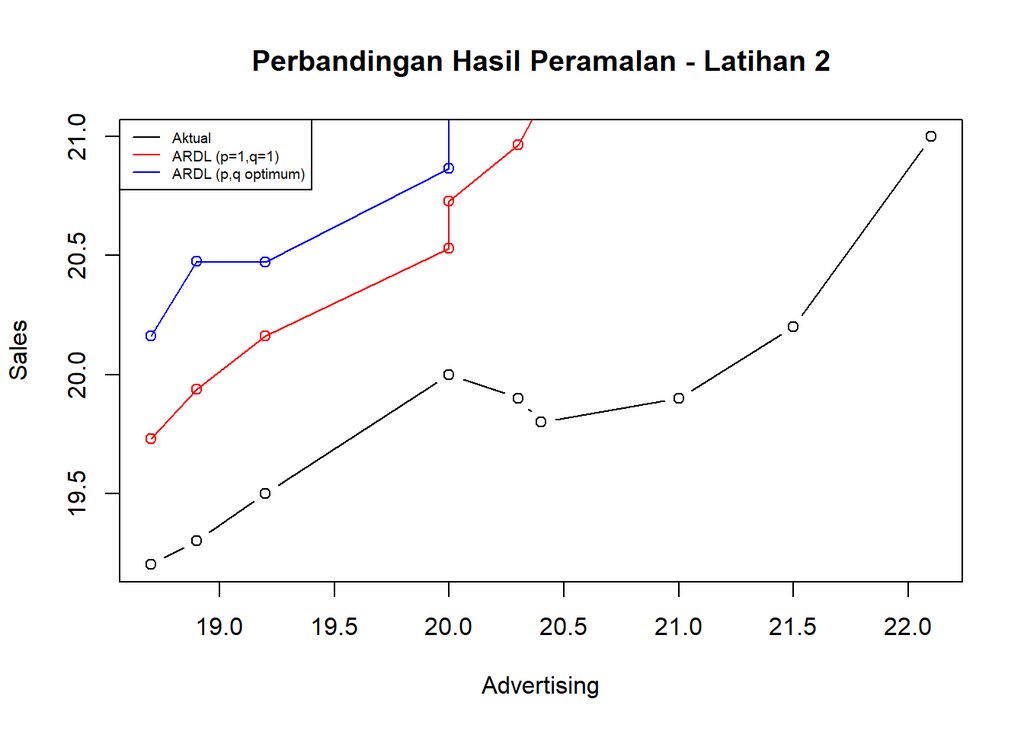

```r
par(mfrow = c(1,1))
plot(test2$advertising, test2$sales, type = "b", col = "black",
     xlab = "Advertising", ylab = "Sales", main = "Perbandingan Hasil Peramalan - Latihan 2")
points(test2$advertising, fore2.ardl$forecasts, col = "red");     lines(test2$advertising, fore2.ardl$forecasts, col = "red")
points(test2$advertising, fore2.ardl.opt$forecasts, col = "blue"); lines(test2$advertising, fore2.ardl.opt$forecasts, col = "blue")
legend("topleft", c("Aktual", "ARDL (p=1,q=1)", "ARDL (p,q optimum)"),
       lty = 1, col = c("black", "red", "blue"), cex = 0.6)
```

# Kesimpulan

**Latihan 1 (Market Share ~ Price):** Berdasarkan pencarian `finiteDLMauto()`, lag optimum berada pada $q=6$ (AIC $=-4,064$; baris $q=7$ sampai $q=10$ diabaikan karena AIC $=-\infty$, tanda model jenuh/overfit). Model distributed lag dengan $q=6$ menghasilkan MAPE data uji $6,37\%$, sedikit lebih baik dibanding model baseline $q=2$ (MAPE $7,06\%$). Dengan demikian, **model DLM dengan $q=6$ dipilih sebagai model terbaik**, meskipun perlu dicatat model ini memiliki derajat bebas sisaan yang sangat kecil (hanya 1), sehingga hasil estimasinya kurang stabil dan idealnya divalidasi lebih lanjut dengan data yang lebih banyak.

**Latihan 2 (Sales ~ Advertising):** Pencarian `ardlBoundOrders()` memberikan orde optimum $(p=9,q=5)$ berdasarkan AIC data latih ($-52,878$), jauh lebih kecil dibanding model baseline $(p=1,q=1)$ ($\text{AIC}=-19,182$). Namun, pada data uji, model $(p=9,q=5)$ justru memiliki MAPE lebih besar ($7,32\%$) dibanding model baseline $(p=1,q=1)$ ($\text{MAPE}=4,85\%$) — indikasi kuat *overfitting* karena model $(p=9,q=5)$ menggunakan terlalu banyak parameter relatif terhadap jumlah data latih yang tersisa. Dengan demikian, **model ARDL$(1,1)$ (bukan hasil pencarian AIC otomatis) yang dipilih sebagai model terbaik** untuk kasus Sales terhadap Advertising ini, karena performanya jauh lebih baik dan stabil pada data uji.

**Catatan umum:** Kedua latihan ini menunjukkan bahwa **pemilihan model berdasarkan AIC pada data latih saja tidak cukup** — model dengan AIC terbaik belum tentu menjadi model dengan generalisasi terbaik pada data baru (data uji). Validasi akurasi pada data uji (di sini menggunakan MAPE) tetap diperlukan sebagai penentu akhir model terbaik, terutama ketika ukuran data latih relatif kecil dibanding jumlah parameter yang diduga.